## In-class worksheet 6

**Feb 1, 2018**

In this worksheet, we will continue to work with the tidyverse libraries:

```r
library(tidyverse)
```

## 1. The msleep dataset

The `msleep` dataset, provided with ggplot2, contains information about sleep and awake times of different mammals:

```r
msleep
```

```
## # A tibble: 83 x 11
##    name   genus vore  order conservation sleep_total sleep_rem sleep_cycle
##    <chr>  <chr> <chr> <chr> <chr>              <dbl>     <dbl>       <dbl>
##  1 Cheet… Acin… carni Carn… lc                 12.1     NA          NA
##  2 Owl m… Aotus omni  Prim… <NA>               17.0      1.80       NA
##  3 Mount… Aplo… herbi Rode… nt                 14.4      2.40       NA
##  4 Great… Blar… omni  Sori… lc                 14.9      2.30        0.133
##  5 Cow    Bos   herbi Arti… domesticated        4.00     0.700       0.667
##  6 Three… Brad… herbi Pilo… <NA>               14.4      2.20        0.767
##  7 North… Call… carni Carn… vu                  8.70     1.40        0.383
##  8 Vespe… Calo… <NA>  Rode… <NA>                7.00    NA          NA
##  9 Dog    Canis carni Carn… domesticated       10.1      2.90        0.333
## 10 Roe d… Capr… herbi Arti… lc                  3.00    NA          NA
## # ... with 73 more rows, and 3 more variables: awake <dbl>, brainwt <dbl>,
## #   bodywt <dbl>
```

```r
msleep %>% filter(vore=="herbi") %>% group_by(order) %>% summarize(count=n()) %>% arrange(desc(count)) # filter -> group -> count
```

```
## # A tibble: 9 x 2
##   order          count
##   <chr>          <int>
## 1 Rodentia          16
## 2 Artiodactyla       5
## 3 Perissodactyla     3
## 4 Hyracoidea         2
## 5 Proboscidea        2
## 6 Diprotodontia      1
## 7 Lagomorpha         1
## 8 Pilosa             1
## 9 Primates           1
```

Verify that the sum of total sleep time (column `sleep_total`) and total awake time (column `awake`) adds up to 24h for all animals in the `msleep` dataset.

```r
# R code goes here.
msleep.new <- mutate(msleep, SumSleepTime = sleep_total+awake)
filter(msleep.new,SumSleepTime != 24)
```

```
## # A tibble: 2 x 12
##   name   genus  vore  order conservation sleep_total sleep_rem sleep_cycle
##   <chr>  <chr>  <chr> <chr> <chr>              <dbl>     <dbl>       <dbl>
## 1 Pilot… Globi… carni Ceta… cd                  2.70     0.100          NA
## 2 Commo… Phoco… carni Ceta… vu                  5.60    NA              NA
## # ... with 4 more variables: awake <dbl>, brainwt <dbl>, bodywt <dbl>,
## #   SumSleepTime <dbl>
```

```r
msleep %>% mutate(DayTime = sleep_total+awake) %>%
  select(name,DayTime) %>%
  filter(DayTime!=24)
```

```
## # A tibble: 2 x 2
##   name            DayTime
##   <chr>             <dbl>
## 1 Pilot whale        24.0
## 2 Common porpoise    24.0
```

Make a list of all the domesticated species in the `msleep` dataset, in alphabetical order. Hint: domesticated species have the entry “domesticated” in the column `conservation`.

```r
msleep %>% filter(conservation=='domesticated') %>%
  select(name) %>% arrange()
```

```
## # A tibble: 10 x 1
##    name
##    <chr>
##  1 Cow
##  2 Dog
##  3 Guinea pig
##  4 Chinchilla
##  5 Horse
##  6 Donkey
##  7 Domestic cat
##  8 Rabbit
##  9 Sheep
## 10 Pig
```

For the different vore classifications, tally how many species are awake for at least 18 hours. Hint: use the function `tally()`.

```r
msleep %>% group_by(vore) %>% tally(awake>=18)
```

```
## # A tibble: 5 x 2
##   vore        n
##   <chr>   <int>
## 1 carni       4
## 2 herbi      11
## 3 insecti     0
## 4 omni        0
## 5 <NA>        1
```

```r
msleep %>% filter(awake>=18) %>% group_by(vore) %>% tally()
```

```
## # A tibble: 3 x 2
##   vore      n
##   <chr> <int>
## 1 carni     4
## 2 herbi    11
## 3 <NA>      1
```

Using the function `top_n()`, identify the top-10 least-awake animals, and list them from least awake to most awake. Explain why this analysis gives you 11 results instead of 10.

```r
msleep %>% select(name, sleep_total) %>%
  top_n(10,sleep_total) %>%
  arrange(sleep_total)
```

```
## # A tibble: 11 x 2
##    name                           sleep_total
##    <chr>                                <dbl>
##  1 Tiger                                 15.8
##  2 Eastern american chipmunk             15.8
##  3 Golden-mantled ground squirrel        15.9
##  4 Arctic ground squirrel                16.6
##  5 Owl monkey                            17.0
##  6 Long-nosed armadillo                  17.4
##  7 North American Opossum                18.0
##  8 Giant armadillo                       18.1
##  9 Thick-tailed opposum                  19.4
## 10 Big brown bat                         19.7
## 11 Little brown bat                      19.9
```

```r
msleep %>% select(name, sleep_total) %>% top_n(10,sleep_total) %>% arrange(desc(sleep_total))
```

```
## # A tibble: 11 x 2
##    name                           sleep_total
##    <chr>                                <dbl>
##  1 Little brown bat                      19.9
##  2 Big brown bat                         19.7
##  3 Thick-tailed opposum                  19.4
##  4 Giant armadillo                       18.1
##  5 North American Opossum                18.0
##  6 Long-nosed armadillo                  17.4
##  7 Owl monkey                            17.0
##  8 Arctic ground squirrel                16.6
##  9 Golden-mantled ground squirrel        15.9
## 10 Tiger                                 15.8
## 11 Eastern american chipmunk             15.8
```

*The 10th has 2.*

Considering only carnivores and herbivores, make a plot of the percent of time each animal is in REM sleep (out of the total sleep time) vs. the animal’s total sleep time. Hint: Use the operator `|` to indicate logical OR in the `filter()` function.

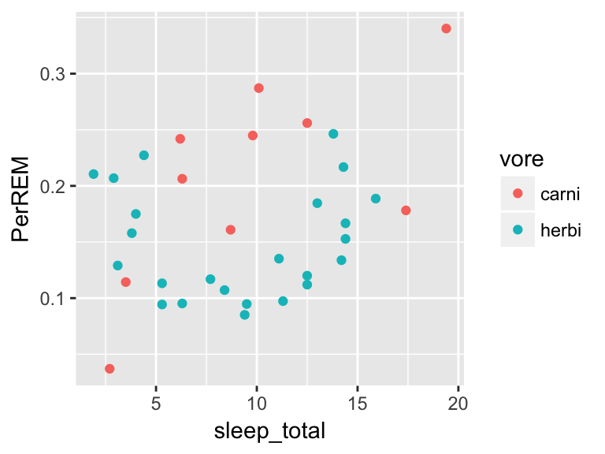

```r
msleep %>% filter(vore=='carni' | vore=='herbi') %>%
  mutate(PerREM=sleep_rem/sleep_total) %>%   ggplot(aes(x=sleep_total,y=PerREM,color=vore))+geom_point()
```

## 2. The diamonds dataset

The `diamonds` dataset provided by ggplot2 provides information about quality and price of 53940 diamonds:

```r
head(diamonds)
```

```
## # A tibble: 6 x 10
##   carat cut       color clarity depth table price     x     y     z
##   <dbl> <ord>     <ord> <ord>   <dbl> <dbl> <int> <dbl> <dbl> <dbl>
## 1 0.230 Ideal     E     SI2      61.5  55.0   326  3.95  3.98  2.43
## 2 0.210 Premium   E     SI1      59.8  61.0   326  3.89  3.84  2.31
## 3 0.230 Good      E     VS1      56.9  65.0   327  4.05  4.07  2.31
## 4 0.290 Premium   I     VS2      62.4  58.0   334  4.20  4.23  2.63
## 5 0.310 Good      J     SI2      63.3  58.0   335  4.34  4.35  2.75
## 6 0.240 Very Good J     VVS2     62.8  57.0   336  3.94  3.96  2.48
```

The best cuts of diamonds are “Very Good”, “Premium”, and “Ideal”. Make a table that selects only those diamonds, and find the minimum, median, and maximum price for each cut. Hint: The operator `%in%` is helpful for selecting the diamond cuts.

```r
diamonds %>% filter(cut %in% c("Very Good", "Premium", "Ideal")) %>%
  group_by(cut) %>%
  summarize(min.price=min(price), med.price=median(price), max.price=max(price))
```

```
## # A tibble: 3 x 4
##   cut       min.price med.price max.price
##   <ord>         <dbl>     <dbl>     <dbl>
## 1 Very Good       336      2648     18818
## 2 Premium         326      3185     18823
## 3 Ideal           326      1810     18806
```

For each of the different diamond cuts, calculate the mean carat level among the diamonds whose price falls within 10% of the most expensive diamond for that cut.

```r
diamonds %>% group_by(cut) %>%
  filter(price > 0.9*max(price)) %>%
  summarize(mean.carat=mean(carat))
```

```
## # A tibble: 5 x 2
##   cut       mean.carat
##   <ord>          <dbl>
## 1 Fair            2.73
## 2 Good            2.08
## 3 Very Good       1.97
## 4 Premium         2.08
## 5 Ideal           1.99
```

For each of the different diamond cuts, calculate the mean carat level among the top-10% most expensive diamonds.

```r
diamonds %>% group_by(cut) %>%
  mutate(price_rank = rank(desc(price))) %>% # rank diamonds by price, in descending order
  filter(price_rank < 0.1*max(price_rank)) %>% # pick the top 10%
  summarize(mean.carat=mean(carat))
```

```
## # A tibble: 5 x 2
##   cut       mean.carat
##   <ord>          <dbl>
## 1 Fair            2.04
## 2 Good            1.76
## 3 Very Good       1.71
## 4 Premium         1.88
## 5 Ideal           1.58
```

Make a table that contains the median price for each combination of `cut` and `clarity`, and arrange the final table in descending order of median price.

```r
diamonds %>% group_by( cut, clarity ) %>%
  summarize(med.price = median(price)) %>%
  arrange(desc(med.price))
```

```
## # A tibble: 40 x 3
## # Groups:   cut [5]
##    cut       clarity med.price
##    <ord>     <ord>       <dbl>
##  1 Premium   SI2          4291
##  2 Ideal     SI2          4060
##  3 Very Good SI2          4042
##  4 Good      SI2          3770
##  5 Fair      SI2          3681
##  6 Ideal     I1           3674
##  7 Premium   SI1          3618
##  8 Fair      SI1          3528
##  9 Very Good I1           3283
## 10 Premium   I1           3261
## # ... with 30 more rows
```

Now arrange the same table first by cut and then within each cut group by median price.

```r
diamonds %>% group_by( cut, clarity ) %>%
  summarize(med.price = median(price)) %>%
  arrange(desc(cut), desc(med.price))
```

```
## # A tibble: 40 x 3
## # Groups:   cut [5]
##    cut     clarity med.price
##    <ord>   <ord>       <dbl>
##  1 Ideal   SI2          4060
##  2 Ideal   I1           3674
##  3 Ideal   SI1          2537
##  4 Ideal   VS1          1813
##  5 Ideal   VS2          1689
##  6 Ideal   VVS2         1330
##  7 Ideal   VVS1         1114
##  8 Ideal   IF           1022
##  9 Premium SI2          4291
## 10 Premium SI1          3618
## # ... with 30 more rows
```

## 3. If this was easy

For the `diamonds` data set, using the function `do()`, fit a linear model of price vs. carat separately for each cut. Then make a table that holds the resulting intercepts and slopes.

```r
diamonds %>% group_by(cut) %>%
  do(lm.result = lm(price ~ carat, data=.)) -> fitted.models
do(fitted.models, data.frame(cut=.$cut,
                             intercept=coef(.$lm.result)[1],
                             slope=coef(.$lm.result)[2]))
```

```
## Source: local data frame [5 x 3]
## Groups: <by row>
##
## # A tibble: 5 x 3
##   cut       intercept slope
## * <ord>         <dbl> <dbl>
## 1 Fair          -1839  5924
## 2 Good          -2423  7480
## 3 Very Good     -2418  7936
## 4 Premium       -2380  7808
## 5 Ideal         -2300  8192
```